# Meaningfulness7v1(color)

Prolific

Cognitive Neuroscience Lab @ Yonsei Univ

2024-12-21

```r
set.seed(1234567) # for reproducibility
options("scipen" = 100) # https://rfriend.tistory.com/224

pacman::p_load(tidyverse, psych, knitr, rstatix, gghalves, ggpubr, BayesFactor, emmeans)
options(dplyr.summarise.inform=FALSE) # suppress warning in regards to regrouping

options(knitr.kable.NA = '')
klippy::klippy()
```

# 1 Demographic

2024년 12월 7일에 Prolific에서 피험자 61명을 모집하였다.

```r
demographic <- bind_rows(list(
  read.csv('M7v1data/data_exp_203230-v5_questionnaire-f86v.csv', header = T),
  read.csv('M7v1data/data_exp_203230-v6_questionnaire-f86v.csv', header = T)))
dim(demographic)
## [1] 430  64

dg <- demographic %>%
  filter(Key == "value") %>%
  select(Participant.Private.ID,
         Object.ID,
         Response) %>%
  rename(Subject = Participant.Private.ID,
         Query = Object.ID) %>%
  mutate(Query = factor(Query,
                        levels = c('object-7', 'object-8'),
                        labels = c('gender', 'age'))) %>%
  pivot_wider(id_cols = c(Subject),
              names_from = Query,
              values_from = Response) %>%
  mutate(Subject = factor(Subject),
         gender = factor(gender),
         age = as.numeric(age))

dg %>%
  group_by(gender) %>%
  summarise(n = n()) %>%
  kable(digits = 3, format = "simple", caption = 'demographic: Gender')
```

demographic: Gender

| gender | n |
| --- | --- |
| Female | 23 |
| Male | 38 |

```r
dg %>%
  get_summary_stats(age, type = 'common') %>%
  kable(digits = 3, format = "simple", caption = 'demographic: Age')
```

demographic: Age

| variable | n | min | max | median | iqr | mean | sd | se | ci |
| --- | --- | --- | --- | --- | --- | --- | --- | --- | --- |
| age | 61 | 19 | 35 | 27 | 8 | 27.426 | 4.713 | 0.603 | 1.207 |

# 2 Post-test query

실험 종료 후, 피험자에게 과제에서 단서를 활용했는지 물었다.

```r
postquery <- bind_rows(list(
  read.csv('M7v1data/data_exp_203230-v5_questionnaire-7u53.csv', header = T),
  read.csv('M7v1data/data_exp_203230-v6_questionnaire-7u53.csv', header = T)))
dim(postquery)
## [1] 230  63

pq <- postquery %>%
  filter(Key == "quantised") %>%
  select(Participant.Private.ID,
         Response) %>%
  rename(Subject = Participant.Private.ID,
         Strategy = Response) %>%
  mutate(Subject = factor(Subject),
         Strategy = factor(Strategy))

# 앞뒤 설문 자료를 합친다.
qs <- full_join(dg, pq, by = 'Subject')
qs %>% print(n = Inf)
## # A tibble: 61 × 4
##    Subject  gender   age Strategy
##    <fct>    <fct>  <dbl> <fct>
##  1 12229278 Male      35 1
##  2 12229280 Male      29 <NA>
##  3 12229282 Male      22 1
##  4 12229283 Male      27 1
##  5 12229521 Male      21 2
##  6 12229522 Male      24 1
##  7 12229523 Male      20 2
##  8 12229524 Male      25 1
##  9 12229525 Female    29 2
## 10 12229526 Male      33 <NA>
## 11 12229527 Female    26 1
## 12 12229528 Female    34 1
## 13 12229529 Female    28 1
## 14 12229531 Male      34 2
## 15 12229532 Female    23 2
## 16 12229533 Female    32 3
## 17 12229535 Male      19 2
## 18 12229536 Female    20 1
## 19 12229537 Female    28 1
## 20 12229538 Male      24 1
## 21 12229539 Male      24 1
## 22 12229540 Male      32 1
## 23 12229541 Female    33 1
## 24 12229542 Male      35 1
## 25 12229543 Female    30 2
## 26 12229544 Male      29 1
## 27 12229545 Female    26 1
## 28 12229546 Male      28 1
## 29 12229547 Male      24 1
## 30 12229548 Male      27 1
## 31 12229549 Female    22 <NA>
## 32 12229550 Female    34 1
## 33 12229553 Male      23 1
## 34 12229557 Male      24 2
## 35 12229559 Female    28 2
## 36 12229562 Female    32 3
## 37 12229564 Female    22 2
## 38 12229566 Female    35 1
## 39 12229567 Male      35 3
## 40 12229568 Female    22 1
## 41 12229571 Male      29 1
## 42 12229573 Male      25 2
## 43 12229575 Male      22 2
## 44 12229576 Male      24 2
## 45 12229577 Male      30 1
## 46 12229579 Male      33 1
## 47 12229583 Female    31 3
## 48 12229591 Female    23 1
## 49 12229592 Male      20 <NA>
## 50 12229611 Male      27 2
## 51 12229777 Male      27 1
## 52 12229849 Male      33 1
## 53 12229926 Female    27 1
## 54 12230390 Male      32 1
## 55 12230392 Male      19 1
## 56 12230394 Male      34 1
## 57 12230398 Female    23 1
## 58 12230399 Male      27 1
## 59 12230405 Female    29 1
## 60 12230414 Male      28 2
## 61 12230435 Male      32 <NA>

qs$Strategy[is.na(qs$Strategy)] <- as.factor(3)

qs %>%
  group_by(Strategy) %>%
  summarise(n = n()) %>%
  kable(digits = 3, format = "simple")
```

| Strategy | n |
| --- | --- |
| 1 | 37 |
| 2 | 15 |
| 3 | 9 |

단서를 활용하여 3개의 물체를 기억했는지(`1`) 아니면 단서를 무시하고 6개의 물체를 모두 기억했는지(`2`)에 대해 사후 설문을 실시하였다. 그 결과, 단서를 활용했다는 응답은 37 명으로 대부분의 참가들이 단서를 사용했음 알 수 있었다.  
기타 답변(`3`)으는 “두 물체씩만 기억했다”는 답변(3명)과 “물체가 아닌 색 패턴을 기억했다”(1명)가 있었고, 5명은 미응답자였다.

# 3 Main data

## 3.1 데이터 불러오기

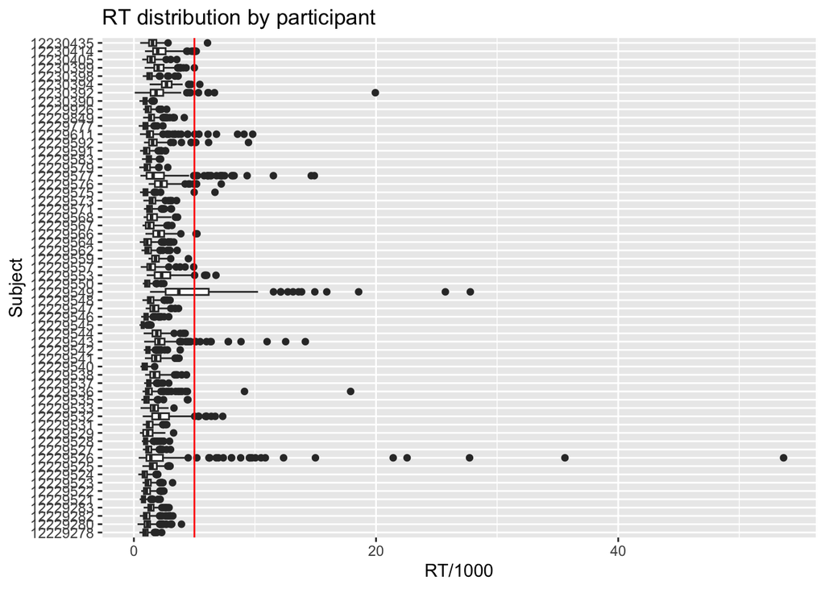

```r
g1 <- bind_rows(list(
  read.csv('M7v1data/data_exp_203230-v5_task-c84a.csv', header = T),  # v01NO1
  read.csv('M7v1data/data_exp_203230-v5_task-pnh5.csv', header = T))) # v04AR2
g2 <- bind_rows(list(
  read.csv('M7v1data/data_exp_203230-v5_task-vxbk.csv', header = T),  # v02NO2
  read.csv('M7v1data/data_exp_203230-v6_task-vxbk.csv', header = T),
  read.csv('M7v1data/data_exp_203230-v5_task-dg8d.csv', header = T),  # v03AR1
  read.csv('M7v1data/data_exp_203230-v6_task-dg8d.csv', header = T)))
g3 <- bind_rows(list(
  read.csv('M7v1data/data_exp_203230-v5_task-4zc6.csv', header = T),  # v03AR1
  read.csv('M7v1data/data_exp_203230-v5_task-8g9j.csv', header = T))) # v02NO2
g4 <- bind_rows(list(
  read.csv('M7v1data/data_exp_203230-v5_task-dwtv.csv', header = T),  # v04AR2
  read.csv('M7v1data/data_exp_203230-v5_task-locf.csv', header = T))) # v01NO1

dim(g1)
## [1] 20525   105
dim(g2)
## [1] 20524   105
dim(g3)
## [1] 21892   105
dim(g4)
## [1] 20527   105

mainTest <- bind_rows(list(g1, g2, g3, g4))
dim(mainTest)
## [1] 83468   105
# str(mainTest)

mt <- mainTest %>%
  filter(Screen == "test") %>%
  select(Participant.Private.ID,
         allocator.3ka9,
         Trial.Number,
         Spreadsheet..suffix,
         Spreadsheet..cue,
         Spreadsheet..tarLoc, # 목표 자극 위치
         Response, # 실제 응답 위치
         Correct,
         Reaction.Time) %>%
  rename(Subject = Participant.Private.ID,
         Group = allocator.3ka9,
         Trials = Trial.Number,
         Stimulus = Spreadsheet..suffix,
         Cue = Spreadsheet..cue,
         Key = Spreadsheet..tarLoc,
         RT = Reaction.Time) %>%
  mutate(Subject = factor(Subject),
         Stimulus = factor(Stimulus,
                           levels = c('.jpg', '_scram.jpg'),
                           labels = c('Intact', 'Scrambled')),
         Cue = factor(Cue,
                      levels = c(0, 1),
                      labels = c('NoCue', 'RetroCue'))) %>%
  group_by(Subject) %>%
  mutate(SN = cur_group_id(),
         SN = factor(SN)) %>%
  ungroup()

table(mt$Group)/192
##
##   AR1NO2   AR2NO1   NO1AR2   NO2AR1
## 16.00000 15.01042 15.00000 15.00000
table(mt$SN) # 21 참가자들의 시행수가 이상
##
##   1   2   3   4   5   6   7   8   9  10  11  12  13  14  15  16  17  18  19  20
## 192 192 192 192 192 192 192 192 192 192 192 192 192 192 192 192 192 192 192 192
##  21  22  23  24  25  26  27  28  29  30  31  32  33  34  35  36  37  38  39  40
## 194 192 192 192 192 192 192 192 192 192 192 192 192 192 192 192 192 192 192 192
##  41  42  43  44  45  46  47  48  49  50  51  52  53  54  55  56  57  58  59  60
## 192 192 192 192 192 192 192 192 192 192 192 192 192 192 192 192 192 192 192 192
##  61
## 192
# table(mt$Subject, mt$Correct)
# table(mt$Subject, mt$Stimulus)

# 문제 참가자 제거
mt <- rm_subject(mt, c(21))
## 1 removed & 60 left
table(mt$Group)/192
##
## AR1NO2 AR2NO1 NO1AR2 NO2AR1
##     16     14     15     15

# 참가자별 반응시간 분포
mt %>%
  ggplot(aes(x = Subject, y = RT/1000)) +
  geom_boxplot() +
  geom_hline(yintercept = 5, color = 'red') +
  coord_flip() +
  ggtitle('RT distribution by participant')
```

```r
# # 참가자별 반응시간; 5초 기준
mt %>%
  summarise(n = sum(RT > 5000))
## # A tibble: 1 × 1
##       n
##   <int>
## 1   158

# 5초이상 반응 오답처리하기
mt <- mt %>%
  mutate(Correct = ifelse(RT > 5000, 0, Correct))
```

- SN = 21(AR2NO1): No-cue 조건 42시행 중 실험이 갑자기 중단되고 다시 이어짐. -> 참가자 제거

**반응시간 5초 이상 응답을 오답으로 처리함.**

## 3.2 Outlier Detection

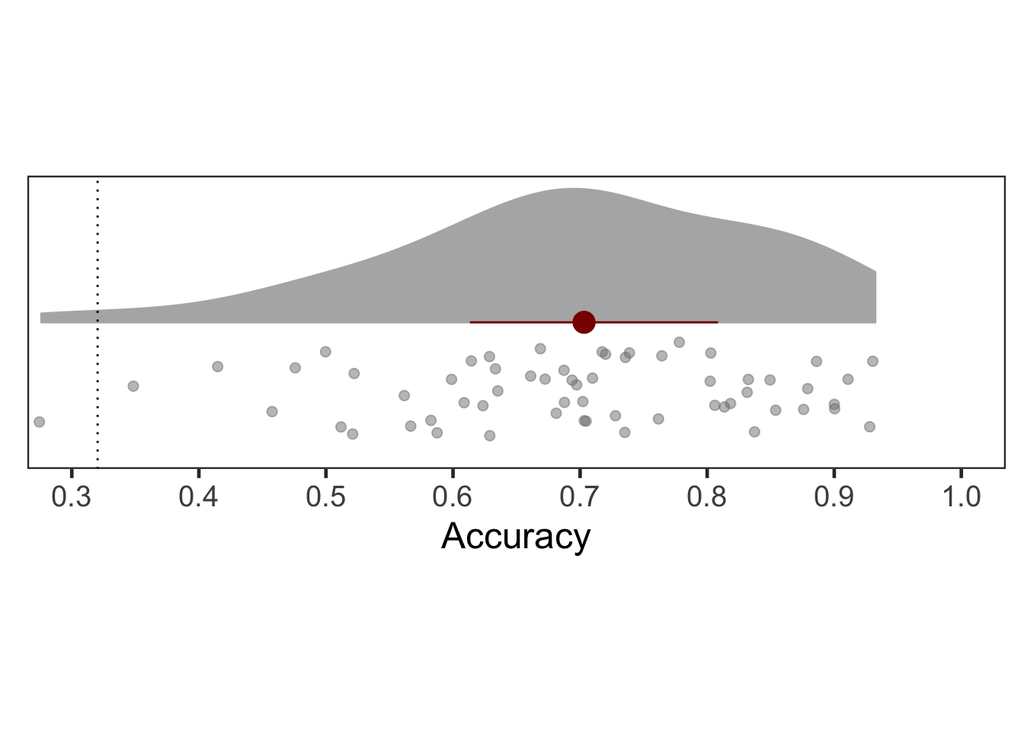

```r
# subject-specific performance
mt.gacc <- mt %>%
  group_by(Subject, SN) %>%
  summarise(M = mean(Correct)) %>%
  ungroup()

mt.gacc %>% print(n = Inf)
## # A tibble: 60 × 3
##    Subject  SN        M
##    <fct>    <fct> <dbl>
##  1 12229278 1     0.719
##  2 12229280 2     0.510
##  3 12229282 3     0.875
##  4 12229283 4     0.719
##  5 12229521 5     0.562
##  6 12229522 6     0.901
##  7 12229523 7     0.630
##  8 12229524 8     0.276
##  9 12229525 9     0.589
## 10 12229526 10    0.349
## 11 12229527 11    0.818
## 12 12229528 12    0.807
## 13 12229529 13    0.839
## 14 12229531 14    0.760
## 15 12229532 15    0.521
## 16 12229533 16    0.703
## 17 12229535 17    0.682
## 18 12229536 18    0.708
## 19 12229537 19    0.833
## 20 12229538 20    0.521
## 21 12229540 22    0.667
## 22 12229541 23    0.729
## 23 12229542 24    0.833
## 24 12229543 25    0.474
## 25 12229544 26    0.927
## 26 12229545 27    0.901
## 27 12229546 28    0.776
## 28 12229547 29    0.734
## 29 12229548 30    0.766
## 30 12229549 31    0.672
## 31 12229550 32    0.734
## 32 12229553 33    0.615
## 33 12229557 34    0.458
## 34 12229559 35    0.609
## 35 12229562 36    0.885
## 36 12229564 37    0.703
## 37 12229566 38    0.911
## 38 12229567 39    0.812
## 39 12229568 40    0.698
## 40 12229571 41    0.854
## 41 12229573 42    0.625
## 42 12229575 43    0.932
## 43 12229576 44    0.849
## 44 12229577 45    0.630
## 45 12229579 46    0.599
## 46 12229583 47    0.703
## 47 12229591 48    0.693
## 48 12229592 49    0.635
## 49 12229611 50    0.635
## 50 12229777 51    0.688
## 51 12229849 52    0.802
## 52 12229926 53    0.802
## 53 12230390 54    0.688
## 54 12230392 55    0.417
## 55 12230394 56    0.568
## 56 12230398 57    0.740
## 57 12230399 58    0.661
## 58 12230405 59    0.583
## 59 12230414 60    0.880
## 60 12230435 61    0.5

gacc.sum <- mt.gacc %>%
  summarise(MN = mean(M)
            , SD = sd(M)
            , MIN = min(M)
            , MAX = max(M)
            , Q1 = quantile(M, prob = .25)
            , MED = median(M)
            , Q3 = quantile(M, prob = .75)
            , IQR = IQR(M)
            , Outlier = Q1 - 1.5 * IQR
            , Extreme = Q1 - 3 * IQR)

mt.gacc %>%
  single_raincloud_plot(.$M, 0.3, 1, 0.1, "Accuracy") +
  geom_hline(yintercept=gacc.sum$Outlier, linetype="dotted") +
  geom_hline(yintercept=gacc.sum$Extreme, linetype='dashed', color='red', linewidth=0.5)
```

```r
mt.gacc %>% identify_outliers(M)
## # A tibble: 1 × 5
##   Subject  SN        M is.outlier is.extreme
##   <fct>    <fct> <dbl> <lgl>      <lgl>
## 1 12229524 8     0.276 TRUE       FALSE
mt %>% filter(SN==8) %>% slice(1L)
## # A tibble: 1 × 10
##   Subject  Group  Trials Stimulus  Cue     Key Response Correct    RT SN
##   <fct>    <chr>   <int> <fct>     <fct> <int> <chr>      <dbl> <dbl> <fct>
## 1 12229524 NO1AR2      1 Scrambled NoCue     1 1              1  977. 8

mt <- rm_subject(mt, c(8))
## 1 removed & 59 left

table(mt$Group)/192 # 역균형 집단 크기 확인
##
## AR1NO2 AR2NO1 NO1AR2 NO2AR1
##     16     14     14     15
```

**8번 참가자 제거.**

## 3.3 N = 59

### 3.3.1 Descriptive Stats

```r
mt.ind <- mt %>%
  group_by(SN, Stimulus, Cue) %>%
  summarise(Accuracy = mean(Correct)) %>%
  ungroup()

mt.ind %>%
  group_by(Stimulus, Cue) %>%
  get_summary_stats(Accuracy, type = "common") %>%
  kable(digits = 3, format = "simple", caption = "Descriptive Stats(N=59)")
```

Descriptive Stats(N=59)

| Stimulus | Cue | variable | n | min | max | median | iqr | mean | sd | se | ci |
| --- | --- | --- | --- | --- | --- | --- | --- | --- | --- | --- | --- |
| Intact | NoCue | Accuracy | 59 | 0.208 | 0.958 | 0.708 | 0.208 | 0.703 | 0.148 | 0.019 | 0.038 |
| Intact | RetroCue | Accuracy | 59 | 0.312 | 1.000 | 0.792 | 0.208 | 0.758 | 0.164 | 0.021 | 0.043 |
| Scrambled | NoCue | Accuracy | 59 | 0.250 | 0.938 | 0.604 | 0.188 | 0.649 | 0.146 | 0.019 | 0.038 |
| Scrambled | RetroCue | Accuracy | 59 | 0.333 | 0.979 | 0.729 | 0.240 | 0.699 | 0.175 | 0.023 | 0.046 |

```r
mt.ind %>%
  group_by(SN, Stimulus, Cue) %>%
  summarise(Accuracy = mean(Accuracy)) %>%
  unite(col = 'Condition', Stimulus:Cue) %>%
  pivot_wider(id_cols = c(SN),
              names_from = Condition, values_from = Accuracy) %>%
  mutate(Intact = Intact_RetroCue - Intact_NoCue, # 화살표 단서 활용 효과
         Scrambled = Scrambled_RetroCue - Scrambled_NoCue) %>%
  select(SN, Intact, Scrambled) %>%
  pivot_longer(cols = c(Intact, Scrambled),
               names_to = 'Stimulus',
               values_to = 'CueBenefit') %>%
  group_by(Stimulus) %>%
  get_summary_stats(CueBenefit, type = "common") %>%
  kable(digits = 3, format = "simple", caption = "CueBenefit(N=59)")
```

CueBenefit(N=59)

| Stimulus | variable | n | min | max | median | iqr | mean | sd | se | ci |
| --- | --- | --- | --- | --- | --- | --- | --- | --- | --- | --- |
| Intact | CueBenefit | 59 | -0.375 | 0.417 | 0.062 | 0.156 | 0.055 | 0.154 | 0.020 | 0.040 |
| Scrambled | CueBenefit | 59 | -0.500 | 0.417 | 0.062 | 0.177 | 0.050 | 0.144 | 0.019 | 0.037 |

### 3.3.2 Graph

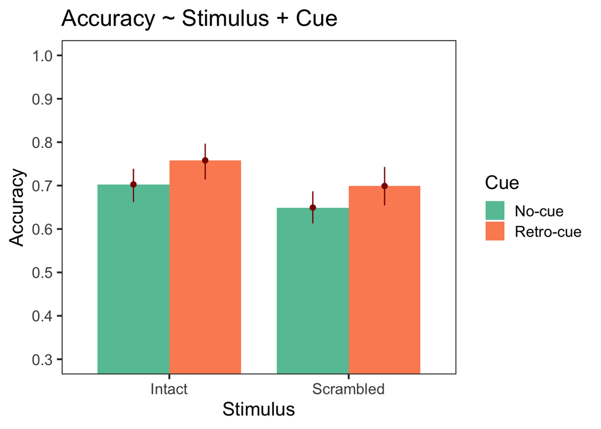

```r
mt.ind %>% ggplot(aes(x = Stimulus, y = Accuracy, fill = Cue)) +
  stat_summary(fun = mean,
               geom = "bar",
               position = position_dodge(width = 0.8),
               aes(fill = Cue),
               width = 0.8) +
  stat_summary(fun.data = "mean_cl_boot",
               position = position_dodge(width = 0.8),
               color = "darkred",
               size = 0.3, show.legend = FALSE) +
  coord_cartesian(ylim = c(0.3, 1), clip = "on") +
  scale_y_continuous(breaks=seq(0.3, 1, by = 0.1)) +
  scale_fill_brewer(labels = c("NoCue" = "No-cue", "RetroCue" = "Retro-cue"),
                    palette = "Set2") +
  labs(x = "Stimulus", y = "Accuracy") +
  ggtitle('Accuracy ~ Stimulus + Cue') +
  theme_bw(base_size = 16) +
  theme(panel.grid.major = element_blank(),
        panel.grid.minor = element_blank())
```

### 3.3.3 Anova

```r
anova_test(
  data = mt.ind, dv = Accuracy, wid = SN,
  within = c(Stimulus, Cue),
  effect.size = "pes"
) %>% get_anova_table() %>%
  kable(digits = 3, format = "simple", caption = "ANOVA")
```

ANOVA

| Effect | DFn | DFd | F | p | p<.05 | pes |
| --- | --- | --- | --- | --- | --- | --- |
| Stimulus | 1 | 58 | 42.519 | 0.000 | * | 0.423 |
| Cue | 1 | 58 | 8.644 | 0.005 | * | 0.130 |
| Stimulus:Cue | 1 | 58 | 0.145 | 0.705 |  | 0.002 |

## 3.4 N = 35 (Compliant Subjects)

Post-query에서 지시를 따라 과제를 수행했다고 응답한 피험자들만 포함.

```r
mt2 <- full_join( mt %>% group_by(Subject) %>% nest(),
                  qs %>% select(Subject, Strategy),
                  by = join_by(Subject)) %>%
  unnest(data) %>%
  ungroup()
slice_sample(mt2, n = 10)
## # A tibble: 10 × 11
##    Subject  Group  Trials Stimulus  Cue        Key Response Correct    RT SN
##    <fct>    <chr>   <int> <fct>     <fct>    <int> <chr>      <dbl> <dbl> <fct>
##  1 12229777 AR1NO2     34 Scrambled NoCue        4 4              1 1181. 51
##  2 12229562 AR2NO1     94 Intact    RetroCue     2 2              1  818. 36
##  3 12229576 NO2AR1      8 Scrambled RetroCue     5 5              1 2581. 44
##  4 12229542 AR2NO1     63 Scrambled RetroCue     3 3              1 2207. 24
##  5 12229546 AR1NO2     12 Intact    RetroCue     1 2              0 1571. 28
##  6 12229550 AR2NO1     46 Scrambled RetroCue     5 5              1  855. 32
##  7 12229529 NO2AR1      3 Scrambled NoCue        3 1              0  831. 13
##  8 12229549 AR1NO2     11 Scrambled NoCue        6 6              1 2908. 31
##  9 12229583 NO1AR2     41 Scrambled NoCue        1 1              1 1655. 47
## 10 12229544 NO2AR1     65 Intact    NoCue        5 5              1 1974. 26
## # ℹ 1 more variable: Strategy <fct>

mt2 %>%
  filter(Strategy == 1) %>%
  summarise(SN = n_distinct(Subject)) # 35명
## # A tibble: 1 × 1
##      SN
##   <int>
## 1    35

mt.ind2 <- mt2 %>%
  filter(Strategy == 1) %>%
  group_by(SN, Stimulus, Cue) %>%
  summarise(Accuracy = mean(Correct)) %>%
  ungroup()
```

### 3.4.1 Descriptive Stats

```r
mt.ind2 %>%
  group_by(Stimulus, Cue) %>%
  get_summary_stats(Accuracy, type = "common") %>%
  kable(digits = 3, format = "simple", caption = "Descriptive Stats(N=35)")
```

Descriptive Stats(N=35)

| Stimulus | Cue | variable | n | min | max | median | iqr | mean | sd | se | ci |
| --- | --- | --- | --- | --- | --- | --- | --- | --- | --- | --- | --- |
| Intact | NoCue | Accuracy | 35 | 0.438 | 0.958 | 0.708 | 0.198 | 0.714 | 0.137 | 0.023 | 0.047 |
| Intact | RetroCue | Accuracy | 35 | 0.396 | 1.000 | 0.833 | 0.146 | 0.806 | 0.130 | 0.022 | 0.045 |
| Scrambled | NoCue | Accuracy | 35 | 0.354 | 0.938 | 0.688 | 0.188 | 0.668 | 0.136 | 0.023 | 0.047 |
| Scrambled | RetroCue | Accuracy | 35 | 0.417 | 0.979 | 0.771 | 0.167 | 0.755 | 0.148 | 0.025 | 0.051 |

```r
mt.ind2 %>%
  group_by(SN, Stimulus, Cue) %>%
  summarise(Accuracy = mean(Accuracy)) %>%
  unite(col = 'Condition', Stimulus:Cue) %>%
  pivot_wider(id_cols = c(SN),
              names_from = Condition, values_from = Accuracy) %>%
  mutate(Intact = Intact_RetroCue - Intact_NoCue, # 화살표 단서 활용 효과
         Scrambled = Scrambled_RetroCue - Scrambled_NoCue) %>%
  select(SN, Intact, Scrambled) %>%
  pivot_longer(cols = c(Intact, Scrambled),
               names_to = 'Stimulus',
               values_to = 'CueBenefit') %>%
  group_by(Stimulus) %>%
  get_summary_stats(CueBenefit, type = "common") %>%
  kable(digits = 3, format = "simple", caption = "CueBenefit(N=35)")
```

CueBenefit(N=35)

| Stimulus | variable | n | min | max | median | iqr | mean | sd | se | ci |
| --- | --- | --- | --- | --- | --- | --- | --- | --- | --- | --- |
| Intact | CueBenefit | 35 | -0.146 | 0.417 | 0.083 | 0.146 | 0.092 | 0.127 | 0.021 | 0.044 |
| Scrambled | CueBenefit | 35 | -0.146 | 0.417 | 0.083 | 0.177 | 0.088 | 0.125 | 0.021 | 0.043 |

실험 1에서는 왜곡된 물체보다 의미 있는 물체에서 단서의 혜택이 더 작았으나, 현재는 의미 있는 물체에서 단서 혜택이 왜곡된 물체보다 약간 더 큰 것으로 확인된다. 그러나 그 차이가 매우 작아, 두 조건 간 단서 혜택이 거의 동일하다고 보는 것이 맞을 것이다.

### 3.4.2 Graph

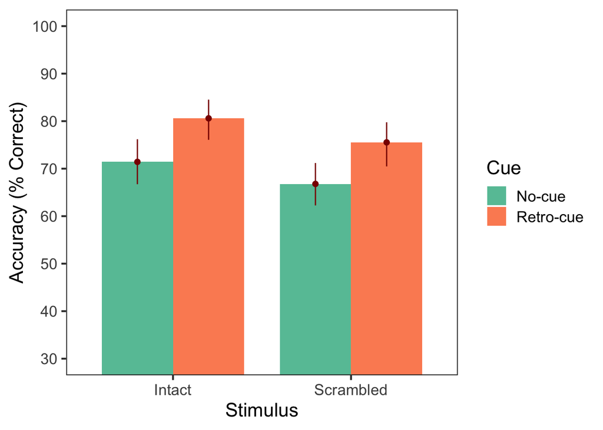

```r
mt.ind2 %>% ggplot(aes(x = Stimulus, y = Accuracy*100, fill = Cue)) +
  stat_summary(fun = mean,
               geom = "bar",
               position = position_dodge(width = 0.8),
               aes(fill = Cue),
               width = 0.8) +
  stat_summary(fun.data = "mean_cl_boot",
               position = position_dodge(width = 0.8),
               color = "darkred",
               size = 0.3, show.legend = FALSE) +
  scale_fill_brewer(labels = c("NoCue" = "No-cue", "RetroCue" = "Retro-cue"),
                    palette = "Set2") +
  labs(x = "Stimulus", y = "Accuracy (% Correct)") +
  coord_cartesian(ylim = c(30, 100), clip = "on") +
  scale_y_continuous(breaks=seq(30, 100, by = 10)) +
  theme_bw(base_size = 16) +
  theme(panel.grid.major = element_blank(),
        panel.grid.minor = element_blank())
```

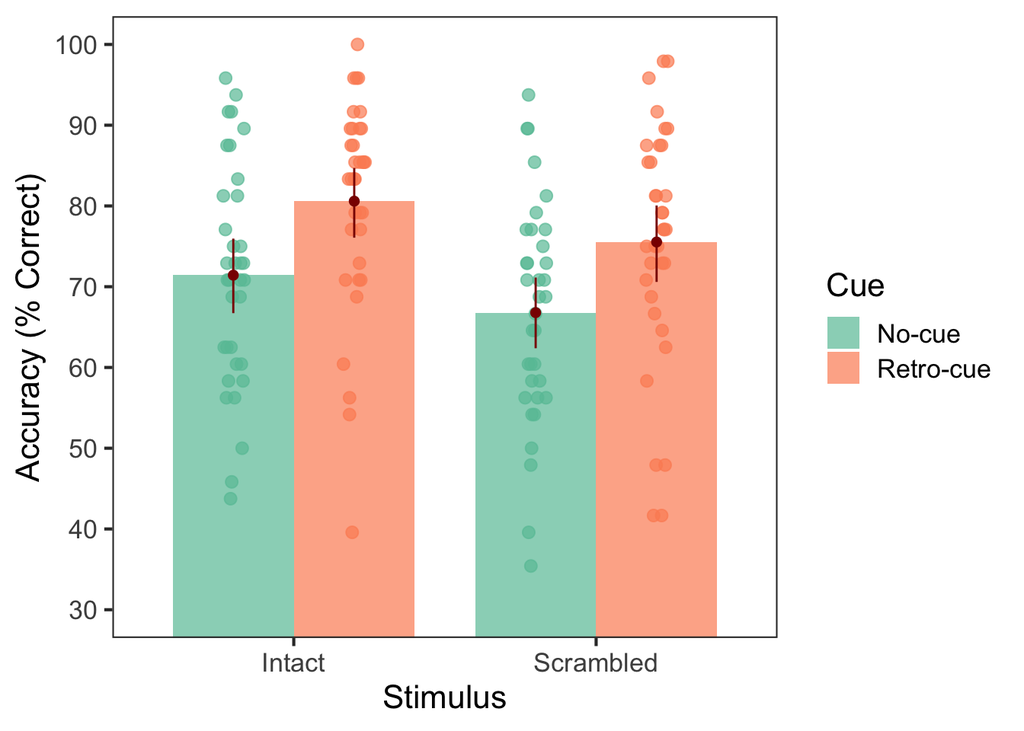

```r
# Accuracy ~ Stimulus + Cue with participants data
mt.ind2 %>%
  ggplot(aes(x = Stimulus, y = Accuracy*100, fill = Cue)) +
  stat_summary(fun = mean,
               geom = "bar",
               position = position_dodge(width = 0.8),
               aes(fill = Cue),
               width = 0.8, alpha = 0.7) +
  geom_point(aes(color = Cue),
             position = position_jitterdodge(jitter.width = 0.15, dodge.width = 0.8),
             size = 2.5, alpha = 0.7,
             show.legend = FALSE) +
  stat_summary(fun.data = "mean_cl_boot",
               position = position_dodge(width = 0.8),
               color = "darkred",
               size = 0.3, show.legend = FALSE) +
  scale_fill_brewer(labels = c("NoCue" = "No-cue", "RetroCue" = "Retro-cue"),
                    palette = "Set2") +
  scale_color_brewer(palette = "Set2") +
  labs(x = "Stimulus", y = "Accuracy (% Correct)") +
  coord_cartesian(ylim = c(30, 100), clip = "on") +
  scale_y_continuous(breaks=seq(30, 100, by = 10)) +
  theme_bw(base_size = 16) +
  theme(panel.grid.major = element_blank(),
        panel.grid.minor = element_blank())
```